# Praca domowa 1

Patryk Wrona

16 marca 2020

## 0.1 Heart disease

Zbiór ‘heart disease’ opisuje podzbiór danych pacjentów z 4 szpitali, a konkretnie pacjentów ze szpitala Cleveland. Dotyczy on chorób serca.

## 0.2 Wczytanie zbiorów danych

```r
hd <- read.csv("./heart_disease_dataset.csv")
```

## 0.3 Usunięcie braków danych

```r
hd <- hd  %>% filter(thal >= 0, ca >= 0)
```

## 0.4 Cechy kategoryczne -> typ factor

Na początek przyjrzę się podstawowym statystykom związanym z naszymi danymi. Zamieniam cechy kategoryczne na typ factor.

```r
# zamieniam plec na zmienną typu factor:
hd$sex <- as.factor(hd$sex)
levels(hd$sex) <- c("female", "male")

hd$cp <- as.factor(hd$cp)
levels(hd$cp) <- c("typical angina",
                   "atypical angina",
                   "non-anginal pain",
                   "asymptotic")

hd$fbs <- as.factor(hd$fbs)
levels(hd$fbs) <- c("<= 120 mg/dl",
                    "> 120 mg/dl")

hd$restecg <- as.factor(hd$restecg)
levels(hd$restecg) <- c("normal",
                        "ST-T wave abnormality",
                        "probable or definite left ventricular hypertrophy")

hd$exang <- as.factor(hd$exang)
levels(hd$exang) <- c("no", "yes")

hd$slope <- as.factor(hd$slope)
levels(hd$slope) <- c("upsloping",
                      "flat",
                      "downsloping")

hd$thal <- as.factor(hd$thal)
levels(hd$thal) <- c("normal",
                     "fixed",
                     "reversable defect")

hd$num <- as.factor(hd$num)
levels(hd$num) <- c("HEART DISEASE",
                    "NO HEART DISEASE")
```

## 0.5 Użycie biblioteki Data Explorer

Idziemy na łatwiznę i używamy Data Explorer. Jest to narzędzie pozwalające na szybki wgląd w dane i wstępne wnioski na podstawie np korelacji. Pozwala to zdecydować np. czy do metod imputacji danych można użyć regresji liniowej w przypadku skorelowanych cech statystycznych. Minusem jest automatyzacja wszystkich wykresów. Raport jest do odczytu w przeglądarce.

```r
DataExplorer::create_report(hd)
```

Raport jest dostępny w oddzielnym pliku ‘report.html’.

## 0.6 Ciekawe wykresy z użyciem rpivotTable

Różnego rodzaju anginy zwiększają p-stwo choroby serca:

```r
rpivotTable::rpivotTable( hd,
             cols = c("sex","cp"),
             rows = "num",
             rendererName = "Col Heatmap",
             aggregatorName = "Count")
```

[interactive table not shown]

Upsloping na eletrokardiogramie zwieksza prawdopodobienstwo choroby serca:

```r
rpivotTable::rpivotTable( hd,
             cols = c("sex","slope"),
             rows = "num",
             rendererName = "Col Heatmap",
             aggregatorName = "Count")
```

[interactive table not shown]

## 0.7 Wykresy kolowe dla cech jakościowych

Postarałem się umieścić cechy jakościowe na wykresach kołowych.

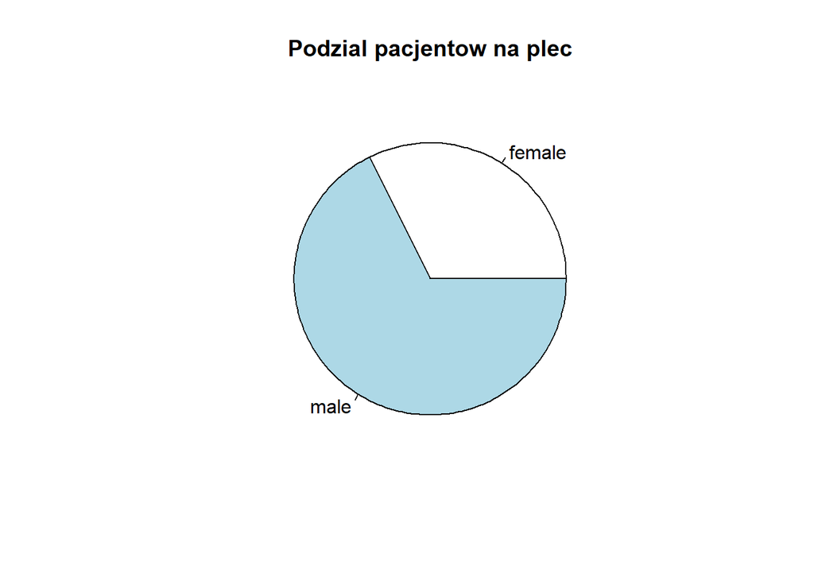

```r
pie(table(hd$sex), main = "Podzial pacjentow na plec")
```

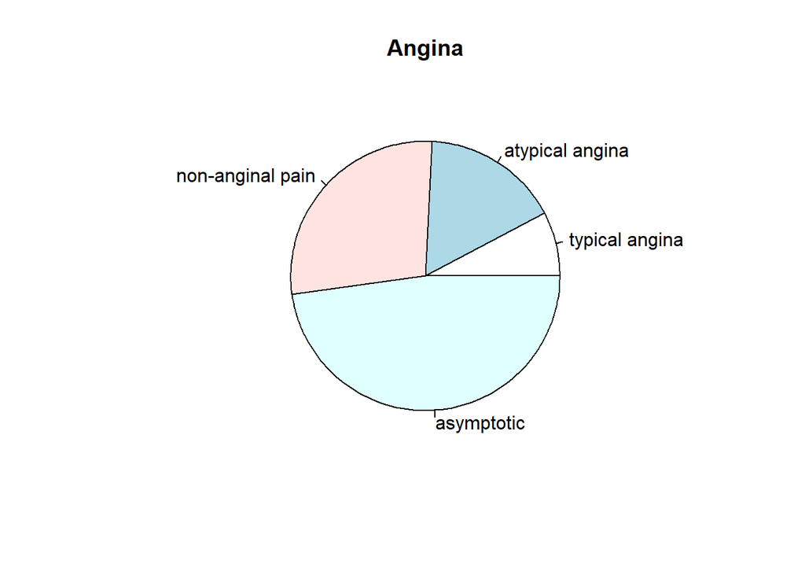

```r
pie(table(hd$cp), main = "Angina")
```

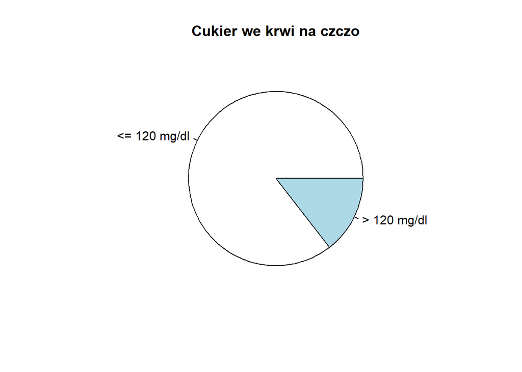

```r
pie(table(hd$fbs), main = "Cukier we krwi na czczo")
```

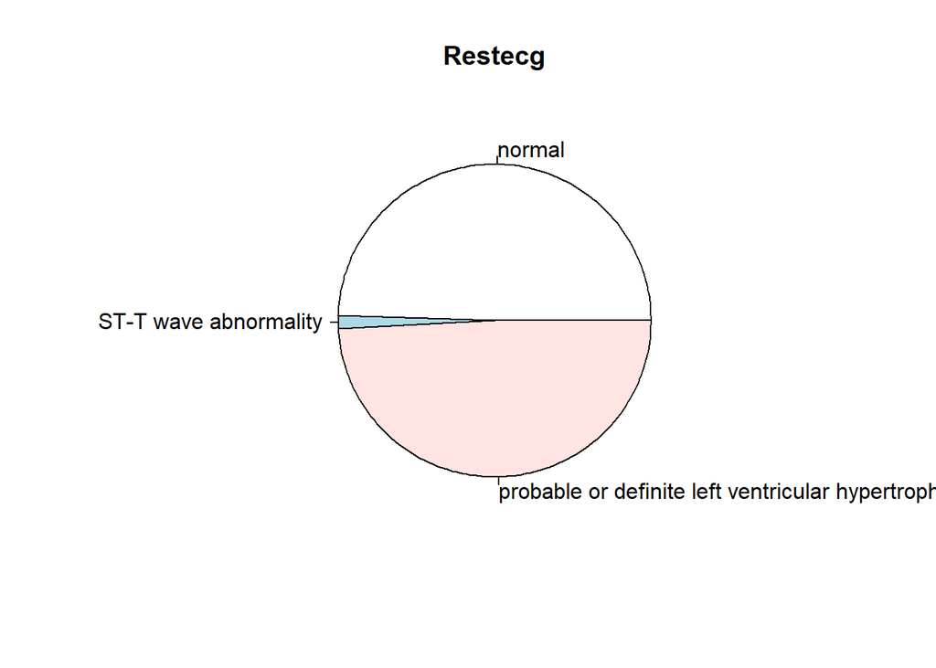

```r
pie(table(hd$restecg), main = "Restecg")
```

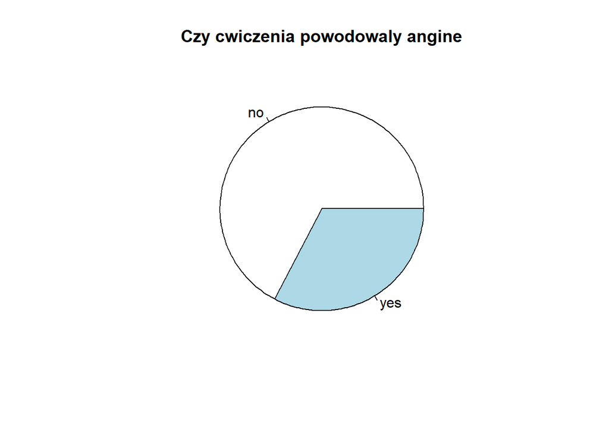

```r
pie(table(hd$exang), main = "Czy cwiczenia powodowaly angine")
```

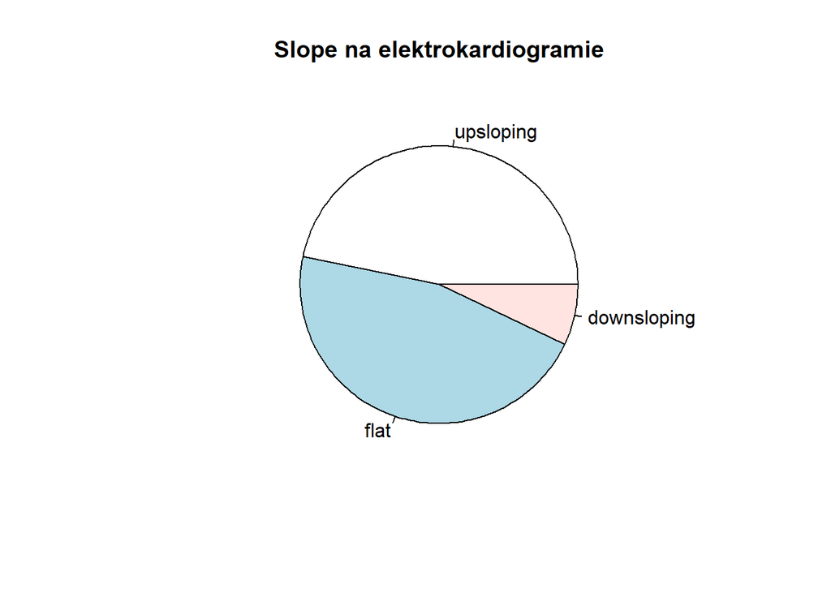

```r
pie(table(hd$slope), main = "Slope na elektrokardiogramie")
```

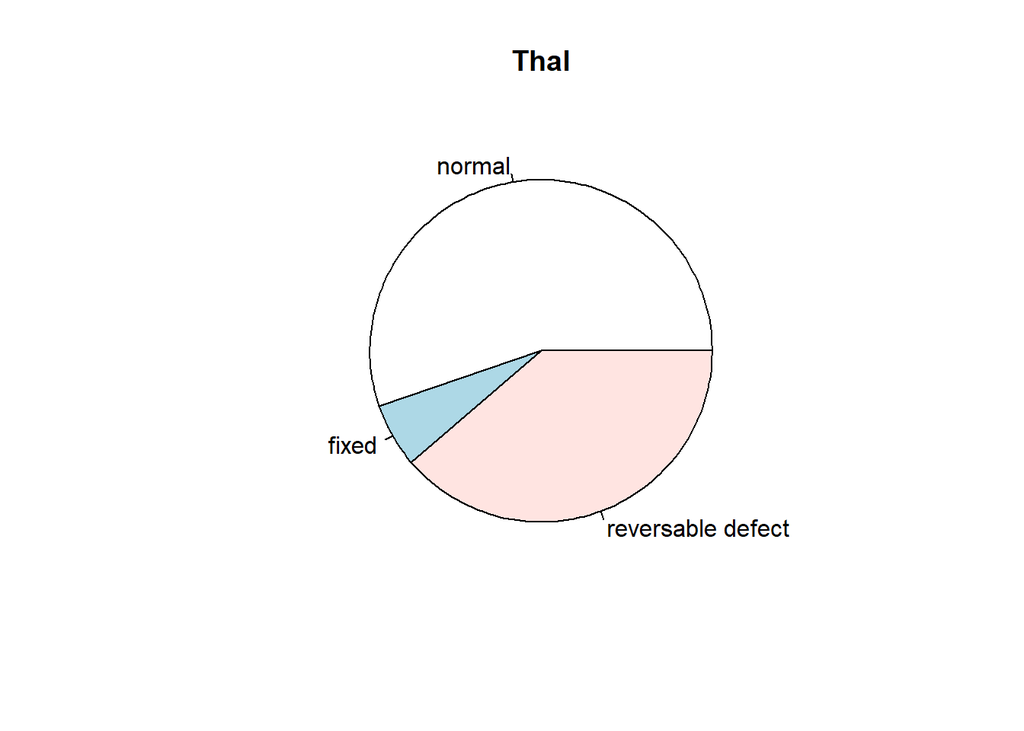

```r
pie(table(hd$thal), main = "Thal")
```

## 0.8 Histogramy ciągłych cech statystycznych

Istnieją różne wzory na optymalną liczbę klas w histogramie. Ja zdecydowałem się wziąć trochę mniej niż sqrt(n), gdzie n jest liczbą obserwacji. Przyjąłem 15 klas.

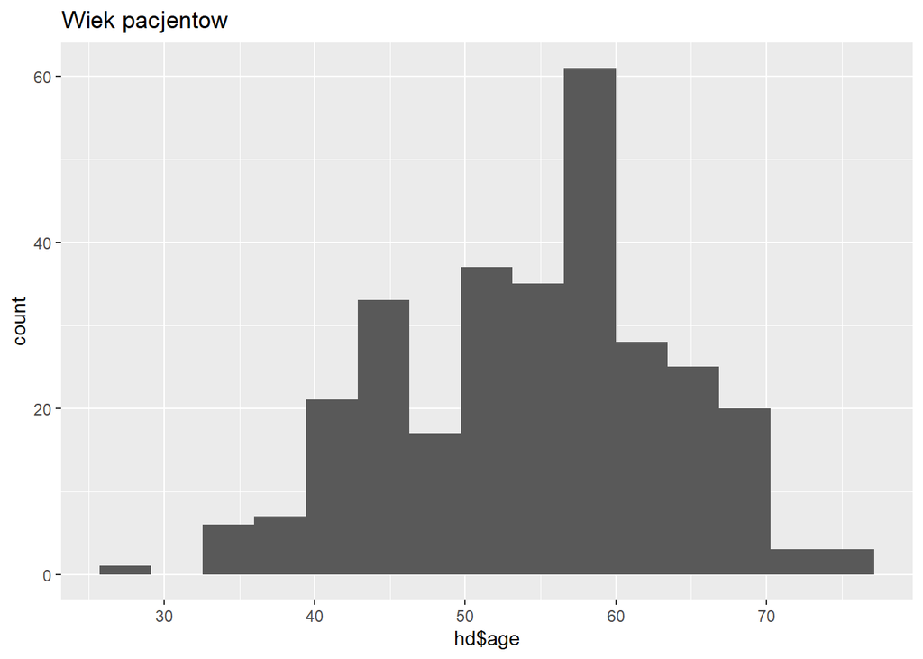

```r
ggplot(hd, aes(hd$age)) + geom_histogram(bins = 15) +
  ggtitle("Wiek pacjentow")
```

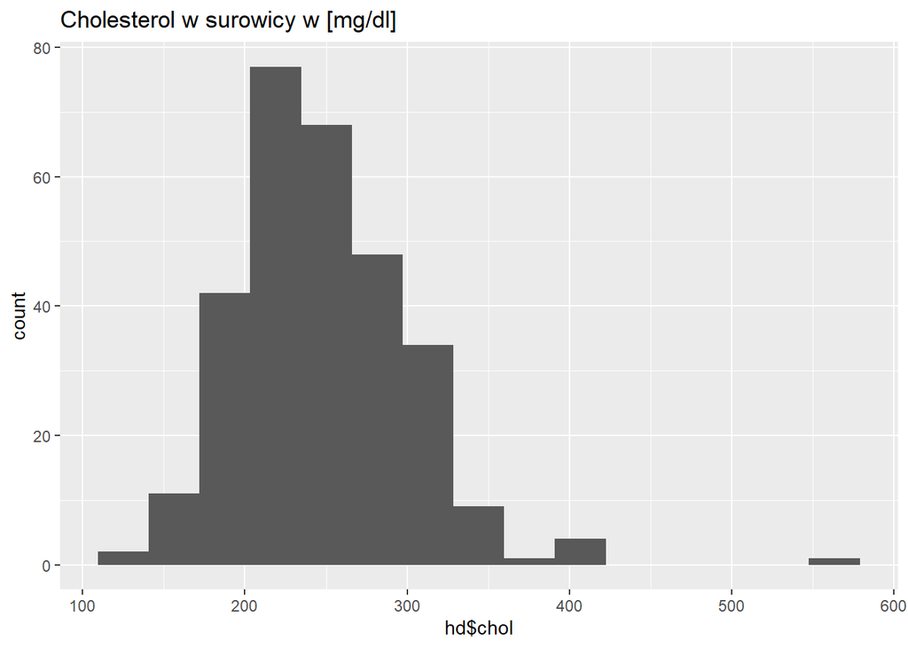

```r
ggplot(hd, aes(hd$chol)) + geom_histogram(bins = 15) +
  ggtitle("Cholesterol w surowicy w [mg/dl]")
```

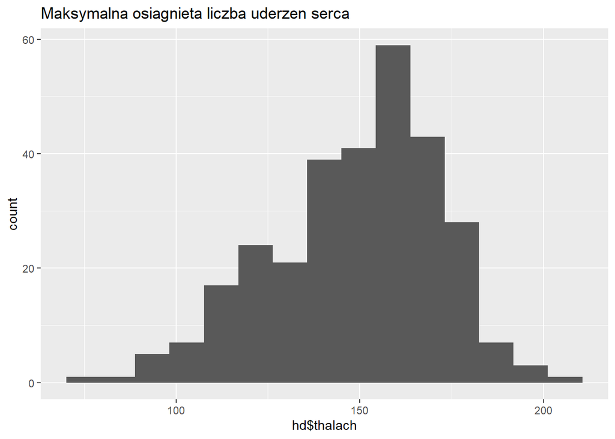

```r
ggplot(hd, aes(hd$thalach)) + geom_histogram(bins = 15)+
  ggtitle("Maksymalna osiagnieta liczba uderzen serca")
```

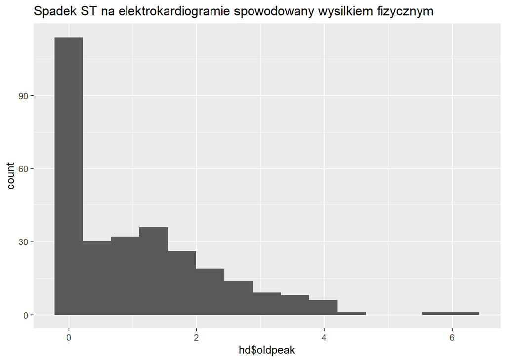

```r
ggplot(hd, aes(hd$oldpeak)) + geom_histogram(bins = 15)+
  ggtitle("Spadek ST na elektrokardiogramie spowodowany wysilkiem fizycznym")
```

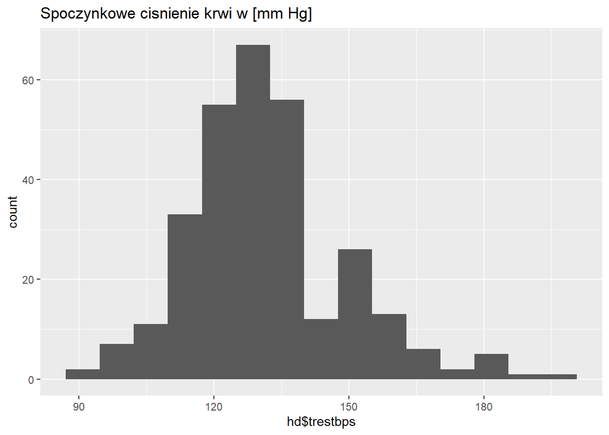

```r
ggplot(hd, aes(hd$trestbps)) + geom_histogram(bins = 15) +
  ggtitle("Spoczynkowe cisnienie krwi w [mm Hg] ")
```